# Data Collection: Analyzing Productivity

October 1, 2018

## Background

## Introduction

In March 2018:

- Decided to use Emacs’ `org-mode`
  - Keeps track of my tasks
  - Keeps track of my working habits
- At the beginning of each task, I “clock in,” work and then “clock out”

My data is a gold mine for me to analyze my productivity

- In this project, I will take this data and perform an observational study on my productivity

## Research Question

On what days of the week am I most productive?

## Data Collection Method

- Data collected using `org-mode`
- An observational study was appropriate: data collected over time
  - Experiment not possible
    - No way to assign which days to “be” productive or “not” productive.
- \(n = 83\)

## Materials

- Computer with Emacs installed
- Time

## Procedure

1. Over a period of time, collect data on time spent working using Emacs’ `org-mode` program.
2. Aggregate this data each day to produce the `workdata.csv` file:

| Date | DayWeek | HoursWorked | Hour | FracHour | Hours |
| --- | --- | --- | --- | --- | --- |
| 30-Mar | Friday | 4:33 | 4 | 0.55 | 4.55 |
| 31-Mar | Saturday | 4:09 | 4 | 0.15 | 4.15 |
| 1-Apr | Sunday | 5:01 | 5 | 0.01666666667 | 5.016666667 |

## Explanatory and Response Variables

- The **explanatory variable** in this case is the day of the week (the `DayWeek` column above), which is a *categorical variable*.
- The **response variable** is the number of hours worked that day.

## Analysis

## Analysis: Overview

- Time to analyze the data
- This analysis uses R, a professional statistical analysis package
  - While it is overkill for this small project, it’s helpful to learn for future use

## Analysis: Part 1

- First, we must mean, SD, and median the hours worked per day based on the day of the week:

| DayWeek | HoursMean | HoursSD | HoursMedian |
| --- | --- | --- | --- |
| Friday | 2.324074 | 1.7197810 | 2.066667 |
| Monday | 4.302564 | 4.2053804 | 3.333333 |
| Saturday | 4.723611 | 3.0300220 | 4.516667 |
| Sunday | 5.083333 | 3.8171215 | 5.016667 |
| Thursday | 2.885000 | 0.6940421 | 2.966667 |
| Tuesday | 3.271795 | 1.3832896 | 3.316667 |
| Wednesday | 2.974359 | 2.1689050 | 3.050000 |

## Analysis: Explanation of Part 1

- Mondays are a bit of a mixed bag in terms of work, around 4.3 hours
  - The third most productive day!
  - Has a standard deviation of *4.2 hours*!
    - Means I either work **extremely hard** on Mondays or **get no work done on that day** (I usually *do* work).
- Fridays: I barely get any work done
  - The beginning of the weekend
- On the other hand, Sundays are (usually) my most productive days

## Analysis: Part 2

- Let’s visualize these results in bar charts:

## Analysis: Part 2

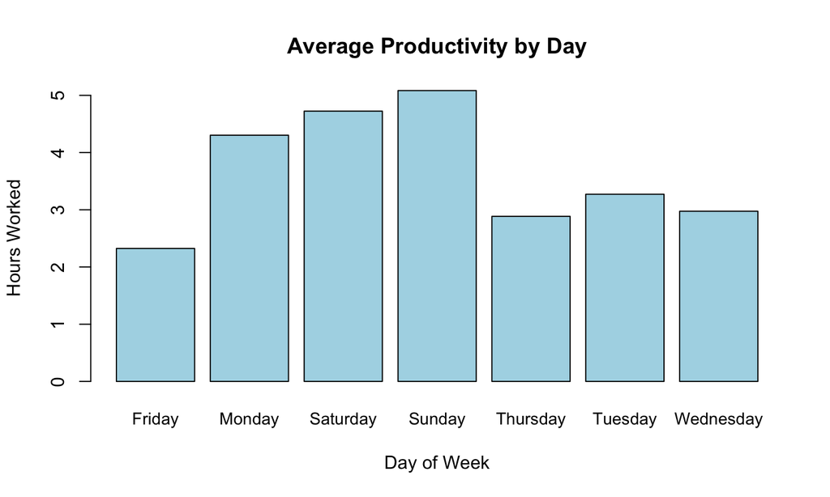

```r
barplot(results$HoursMean, names.arg = results$DayWeek, xlab = 'Day of Week', ylab = 'Hours Worked',
        main = 'Average Productivity by Day', col = rep('lightblue', 7), cex.names = 0.91)
```

## Analysis: Part 2

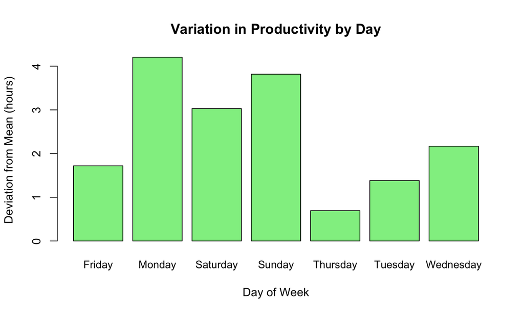

```r
barplot(results$HoursSD, names.arg = results$DayWeek, xlab = 'Day of Week',
        ylab = 'Deviation from Mean (hours)', main = 'Variation in Productivity by Day',
        col = rep('lightgreen', 7), cex.names = 0.91)
```

## Analysis: Part 2

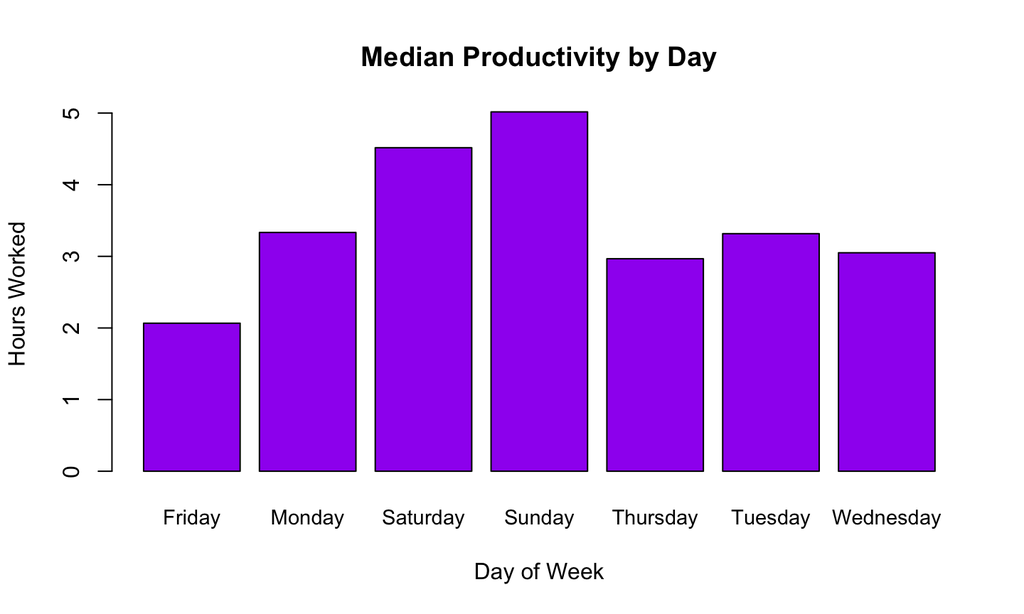

```r
barplot(results$HoursMedian, names.arg = results$DayWeek, xlab = 'Day of Week',
        ylab = 'Hours Worked', main = 'Median Productivity by Day',
        col = rep('purple', 7), cex.names = 0.91)
```

## Conclusion

- I can conclude that my most productive day is Sundays
  - I am least productive on Fridays
- Must account for variation from the daily average productivity
  - Makes my most productive day Thursdays
    - Due to its low \(\sigma\)
    - Relatively high value when \(\mu - \sigma\).

Questions?

### Written analysis available at

### https://applecrazy.github.io/statistics